# Dukes_etal_2021

The rise of affectivism. Nature Human Behaviour, 1–5. https://doi.org/10.1038/s41562-021-01130-8

Last update at: 2023-07-14

Back to index

# Abstract / Key Points

Goal: Incorporating emotions, feelings, motivations, moods, and other affective processes into models of human behaviour and the human mind.

- Such processes have been ignored, typically on the basis that they were irrational, un-measurable, or simply unenlightening.
- However, it has become increasingly difficult to deny that these processes are not only linked to our well-being, but also shape our behaviour and drive key cognitive mechanisms such as attention, learning, memory, and decision-making.

Research on such processes has positively blossomed since then, as growing numbers of dedicated researchers, departments, research centres, journals, and societies contribute to the *affective sciences*—a highly integrative endeavour that spans disciplines, methods, and theories.

We have moved beyond the eras of behaviourism and cognitivism, into the era of affectivism.

The inclusion of affective processes in such models not only explains affective phenomena but, critically, further enhances the power to explain cognition and behaviour

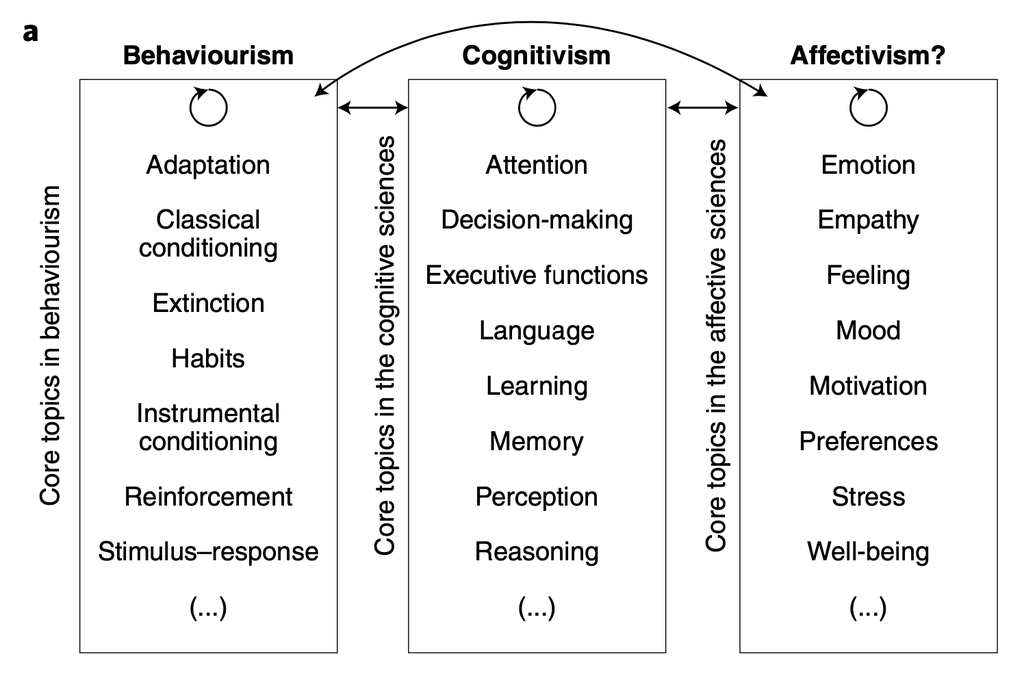

Def of affective phenomenon is elusive. Nonetheless, it seems that affective processes are typically understood to relate to the notion of *(dis) pleasure or valence*, to not necessarily be consciously felt, and to mobilize the organism to deal with events that may be important to that organism. But this should not stop us from studying it.

- In any case, scientific study is beset by questions of terminology: persistent difficulties in formally defining ‘cognition’ did not prevent the transition from behaviourism to cognitivism, and the fact that there is no consensus concerning a formal definition of other important constructs, such as intelligence, religion, culture, and even life, does not preclude fruitful scientific study of them.

Importantly, emotions do not just shape how we interpret the world, but also shape which aspects of the world need our attention and which can safely be ignored: emotions are not just about what is, but also about what matter

Clinical domains:

- a new diagnostic system, proposed by the National Institute of Mental Health (NIMH). The new system relies heavily on emotion-related constructs, including arousal and positive- and negative-valence systems

Affective computing: implementing emotional processes in artificial agents (socially interactive agents, social robotics, chatbots) and systems

Other social sciences than psych:

- Behavioural economists have developed more psychologically realistic assumptions about economic agents—homo economicus—by incorporating affective processes into their theoretical and empirical models of investment behaviour, medical decision-making, bargaining, and issues in political economy such as voting behaviour.
- Anthropology: begun to focus on the cultural modelling of human affective processes, highlighting the intercultural variety of emotion repertoires
- Sociology: complemented this approach with a focus on intracultural plurality and the role of emotions in social collectives

Most anthropologists and sociologists now recognise the significance of emotions in human behaviour and study emotional interactions at the micro-level (individuals or small groups), the meso-level (social institutions), and the macro-level (social structures such as class, age, or gender).

- Education: SEL programs

Emotions are considered fundamental social phenomena, forming the basis for many kinds of social activities and interactions and playing an essential role in socialisation processes, such as affective social learning.

Thus, just as cognition and behaviour can serve both social and non-social functions, so too can affect

Back to index